# Programando IA com R

Basic Building Blocks - Primeiros comandos a se rodar no R!

prof. Elthon Manhas de Freitas

[figure not shown]

## Comandos básicos

O que acontece ao digitar um nome de uma variável qualquer?

```r
valorA
```

```
Error: object 'valorA' not found
```

Parece que a variável `valorA` não existe. Como atribuir um valor a esta variável?

```r
valorA <- 45
```

Poxa, parece que funcionou? E como consultar as variáveis que existem na memória?

```r
ls()
```

```
[1] "valorA"
```

E para consultar o conteúdo desta variável?

```r
valorA
```

```
[1] 45
```

Na verdade, quando se escreve uma instrução qualquer, se o resultado não for atribuído a nenhuma variável, seu valor é impresso no console.

```r
45
```

```
[1] 45
```

```r
valorA
```

```
[1] 45
```

Interessante. É possível criar uma variável a partir de uma operação?

```r
soma1 <- 40 + 49
```

E uma soma usando uma variável?

```r
soma2 <- valorA + 49
```

Vamos consultar o valor das duas variáveis recém-criadas:

```r
soma1
```

```
[1] 89
```

```r
soma2
```

```
[1] 94
```

A forma mais fácil de criar um vetor.

```r
vet <- c(18.1, 19, 13.14)
```

Será que ele foi criado? Vejamos o conteúdo de ‘vet’

```r
vet
```

```
[1] 18.10 19.00 13.14
```

Parece que não tem vírgulas na saída…

E para adicionar algo ao vetor? Como seria?

```r
vet <- c(vet, 78.7)
vet
```

```
[1] 18.10 19.00 13.14 78.70
```

```r
vet <- c(-18, vet)
vet
```

```
[1] -18.00  18.10  19.00  13.14  78.70
```

O mais interessante que vejo são as operações matemáticas com os vetores.

```r
vet * 2;
```

```
[1] -36.00  36.20  38.00  26.28 157.40
```

```r
vet * 10;
```

```
[1] -180.0  181.0  190.0  131.4  787.0
```

```r
vet * 10 + 10;
```

```
[1] -170.0  191.0  200.0  141.4  797.0
```

```r
vet * vet;
```

```
[1]  324.0000  327.6100  361.0000  172.6596 6193.6900
```

Aliás, é possível separar as instruções com `;`, como ocorre com muitas linguagens. Como não é obrigatório, fica a critério da equipe utilizar ou não. Particularmente eu gosto de utilizar se sempre que lembro coloco um `;` entre os comandos.

Os operadores aritméticos básicos são `+`, `-`, `/`, e `^` (ou `**`). Vamos testá-los sem atribuir os resultados a nenhuma variável.

```r
10 + 10;
```

```
[1] 20
```

```r
10 - 5;
```

```
[1] 5
```

```r
10 / 3;
```

```
[1] 3.333333
```

```r
10 ^ 2;
```

```
[1] 100
```

```r
10 ** 2;
```

```
[1] 100
```

Além da divisão `/`, há também operadores para obter o resto da divisão `%%` e o quociente `%/%`

```r
10 / 3
```

```
[1] 3.333333
```

```r
10 %% 3
```

```
[1] 1
```

```r
10 %/% 3
```

```
[1] 3
```

Para nos lembrar:

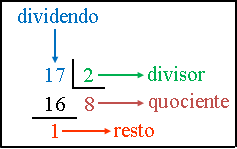

## Obtendo ajuda no R

Alguns comandos para procurar por ajuda:

```
?rnorm
help.search("rnorm")
args("rnorm")
```

### Programando IA com R

[interactive chart not shown]

*Elthon Manhas de Freitas - São Paulo - 2018*